# Research on NFL data

Team 2 (Patrick Berthelsen, Natascha Svarre, Alex Rye & Nino Krupic)

21/11/2021

## 1 Introduction

In the following introduction section, the business problem and research questions of this report are presented and described. Additionally, the scope is defined.

### 1.1 Business case

This report is motivated by the rising issue of Bet356, who are experiencing difficulties predicting the outcome of NFL results and thereby losing profits to customers betting on American football. Bet356 has hired four consultants from Oana Inc. to make a report on how they can optimise their current parameters for predicting NFL outcomes. The NFL department is currently a loss-making business and bettors have proven to have substantially higher payout percentages on NFL games compared to other sports. Oana Inc. seeks to provide Bet356 with an accurate analysis of what parameters are important for predicting NFL outcome and what they should focus on what factors to prioritise when creating bets on the NFL.

### 1.2 Research question

This report seeks to investigate what factors are most important when predicting the success of an NFL team.

## 2 Theory

## 3 Data

### 3.1 Data cleaning

#### 3.1.1 Data on NFL season standings 2000-2019

#### 3.1.2 Data on NFL game results 2000-2019

## 4 Hypotheses

## 5 Analysis

### 5.1 EDA

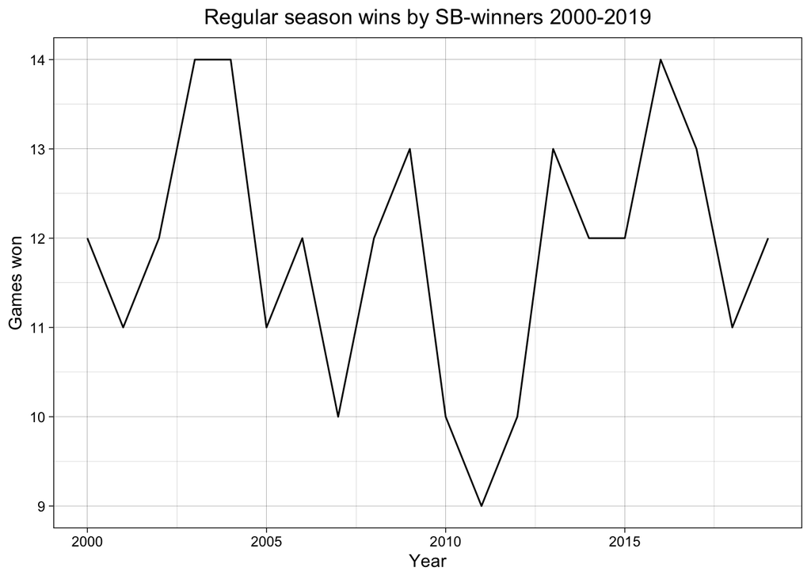

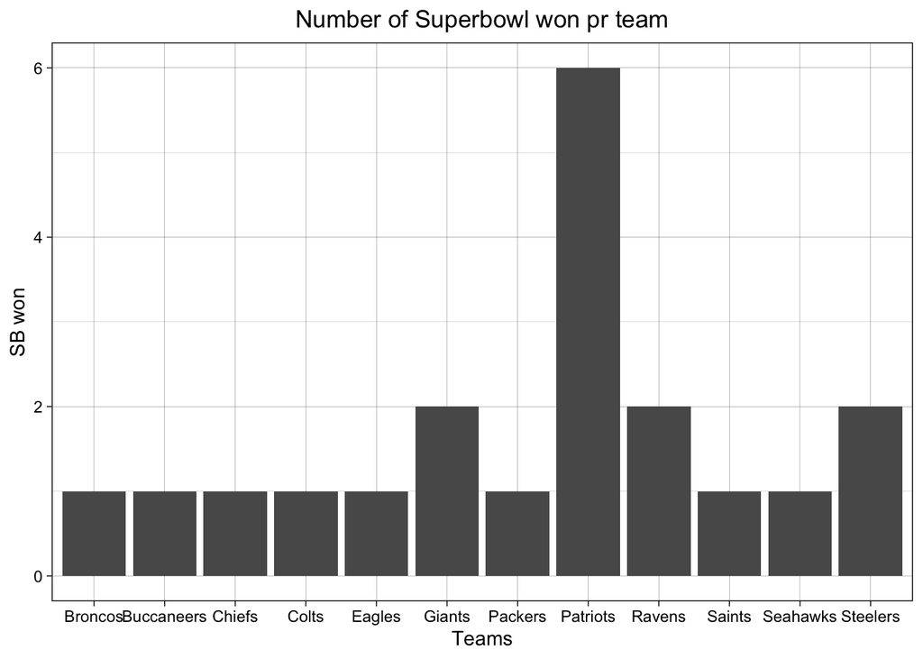

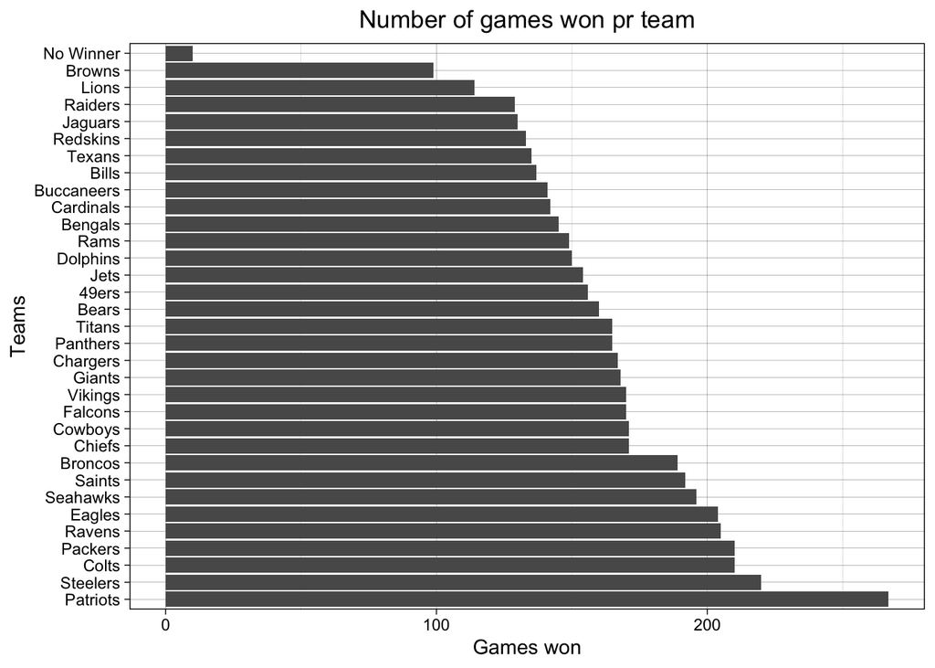

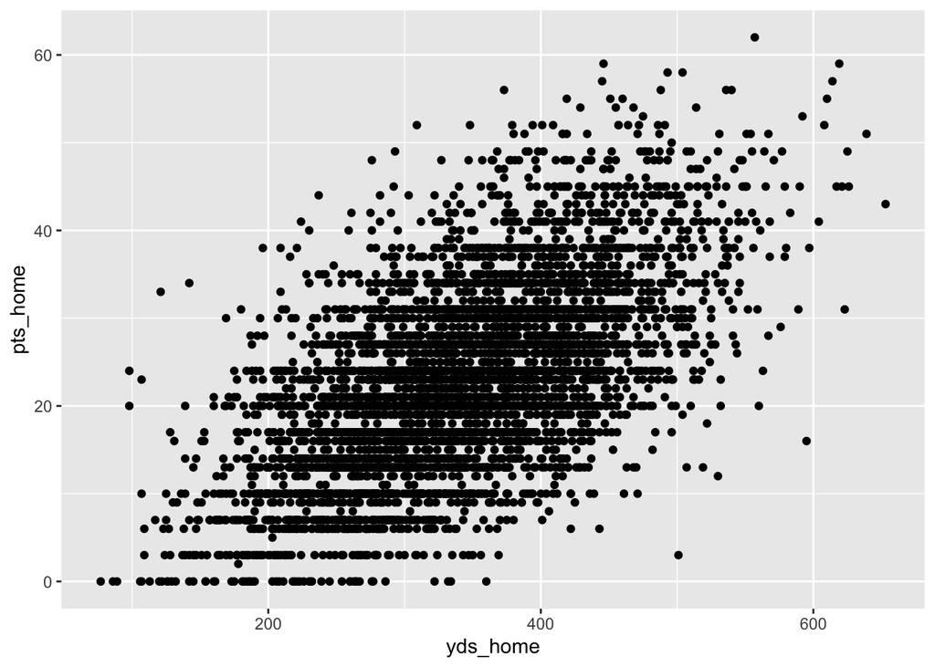

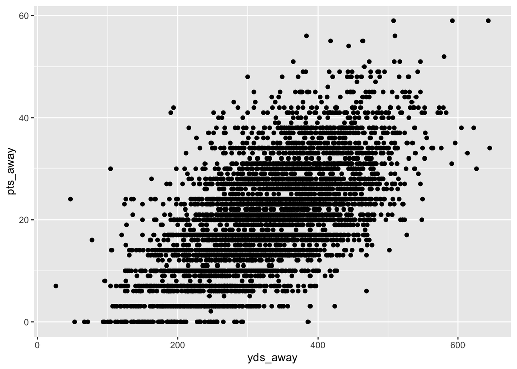

#### 5.1.1 Wordcloud

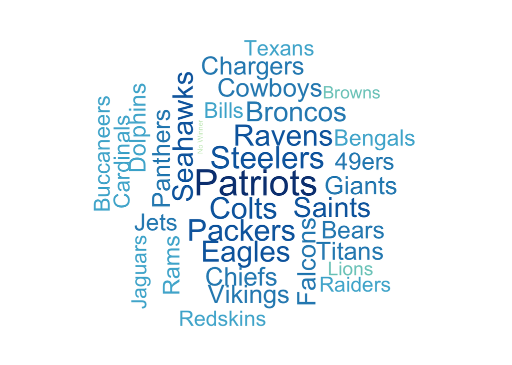

### 5.2 Regression models

#### 5.2.1 Games dataset

#### 5.2.2 Standings dataset (playoff as succes)

#### 5.2.3 Standings dataset (Super Bowl win as success)

## 6 Prediction models

### 6.1 Games dataset

#### 6.1.1 Naive Bayes

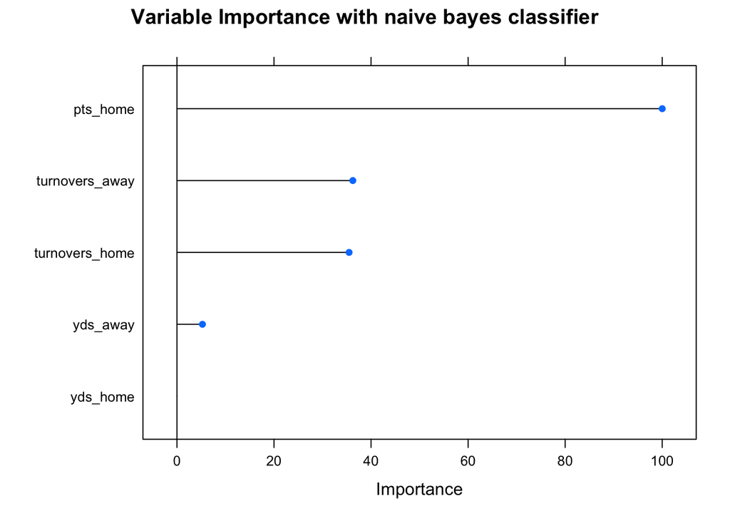

#### 6.1.2 SVM (Support Vector Machine)

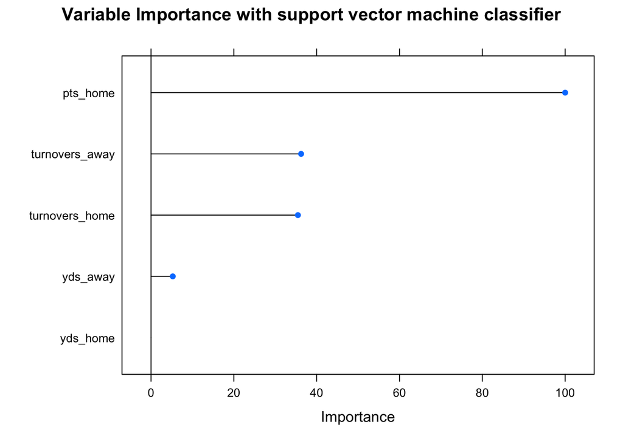

#### 6.1.3 K-nearest neighbour

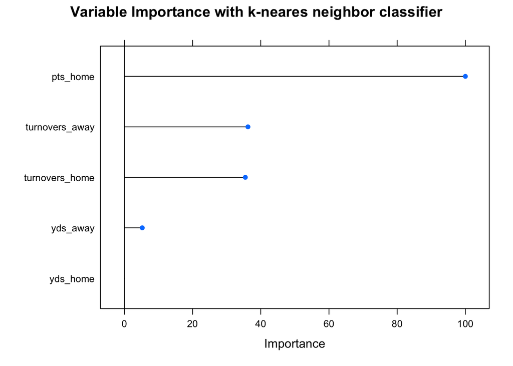

#### 6.1.4 Decision tree

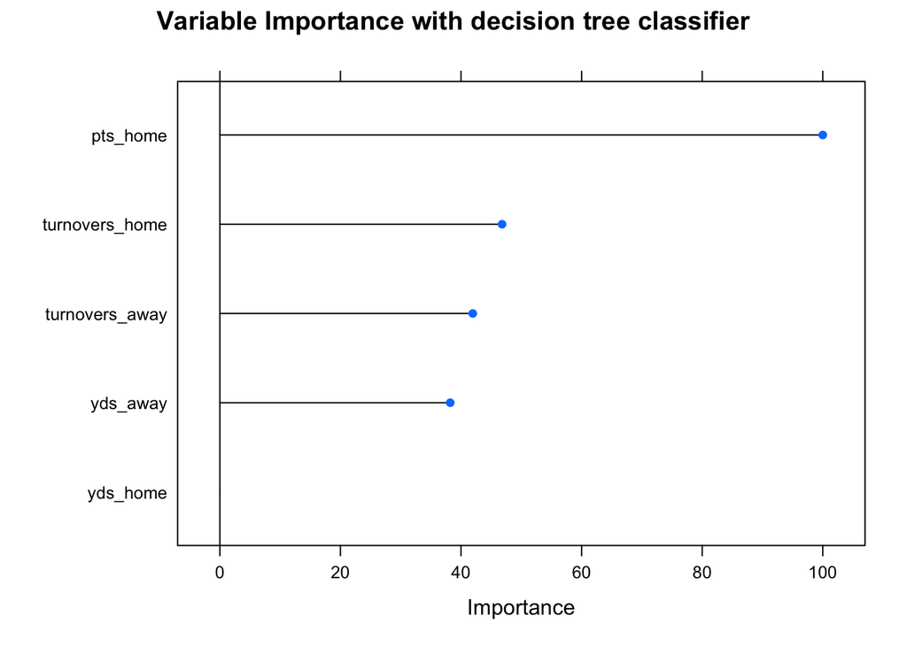

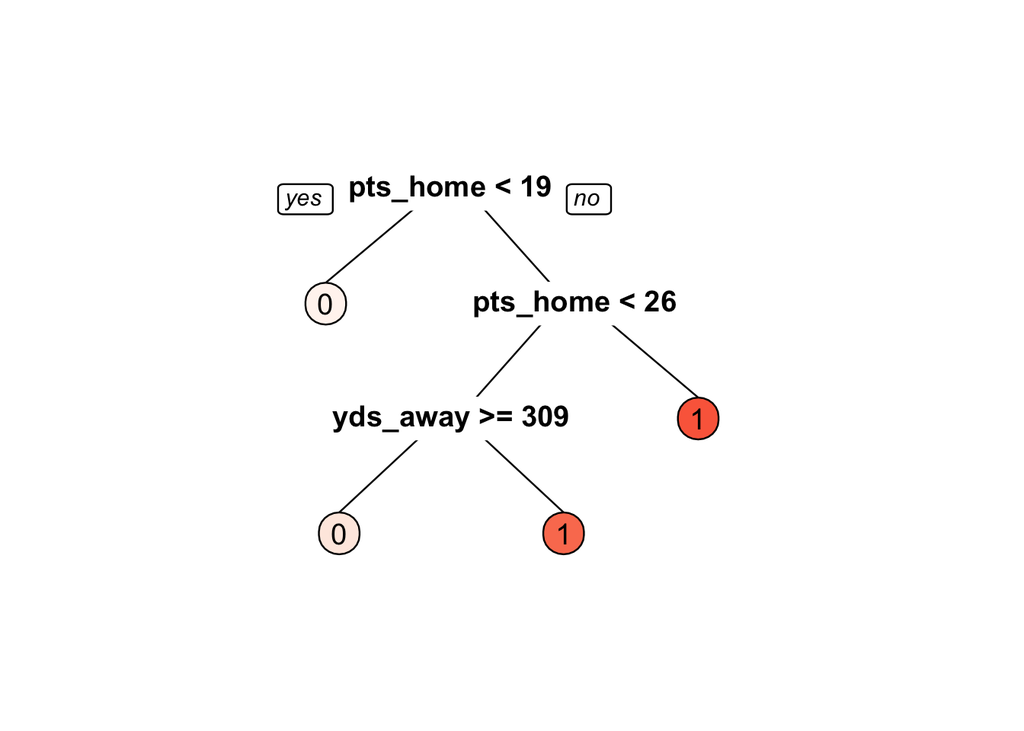

### 6.2 Standings dataset (playoffs as success parameter)

#### 6.2.1 Naive Bayes

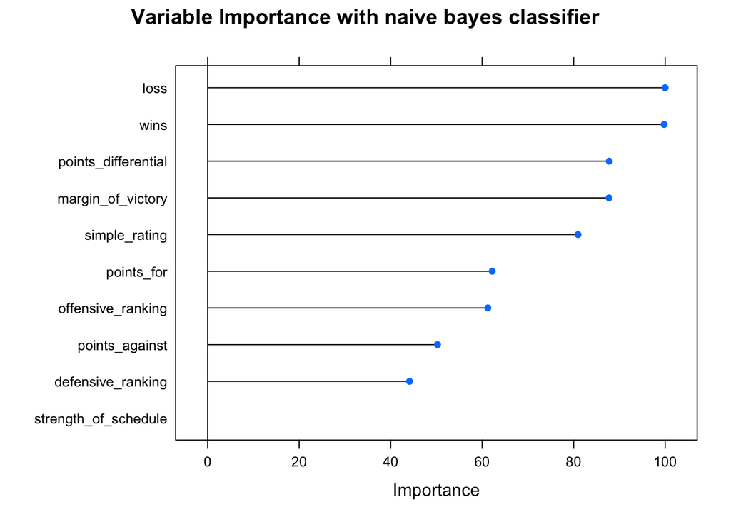

#### 6.2.2 SVM

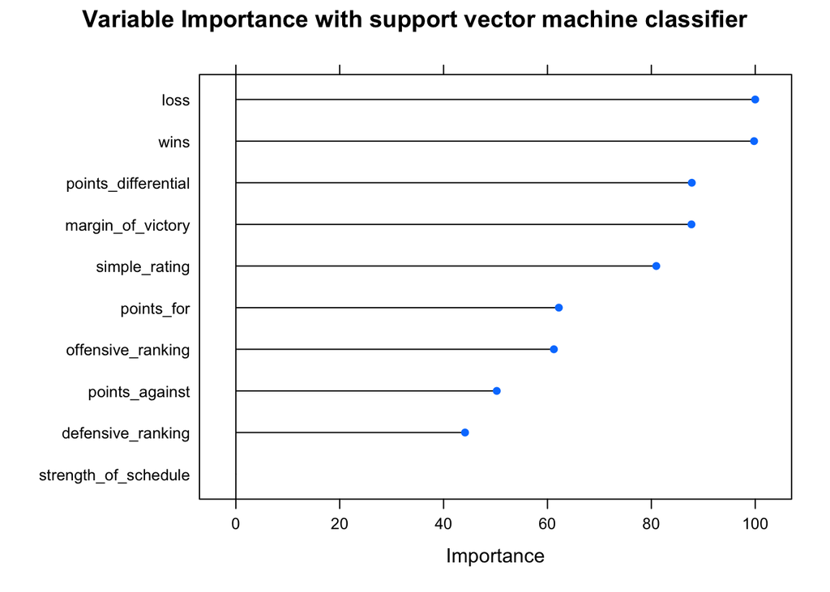

#### 6.2.3 KNN

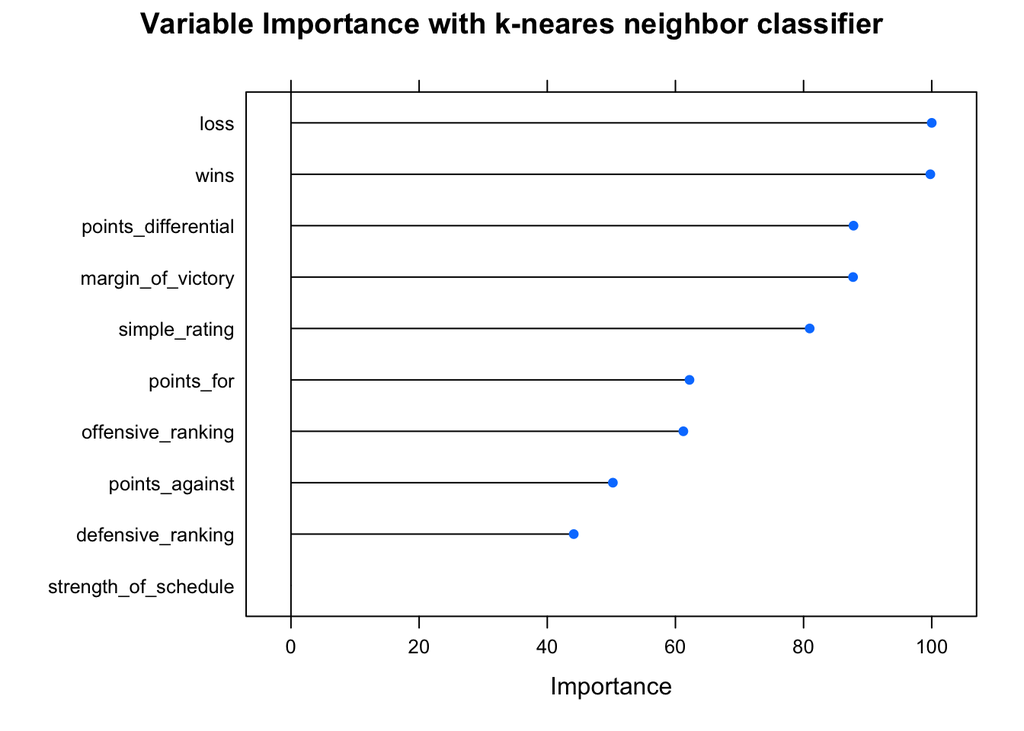

#### 6.2.4 Decision tree

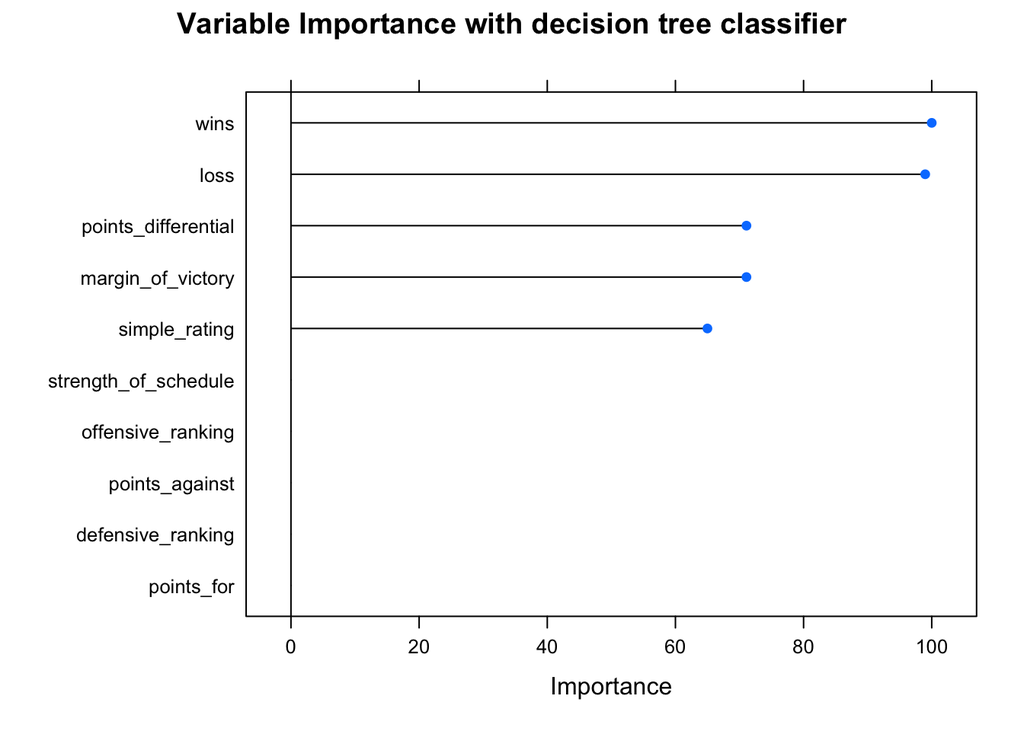

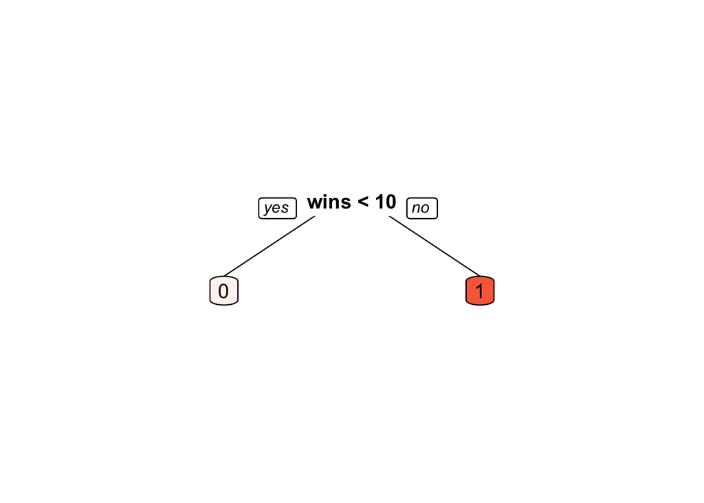

### 6.3 Standings dataset (winning superbowl as success parameter)

#### 6.3.1 Naive Bayes

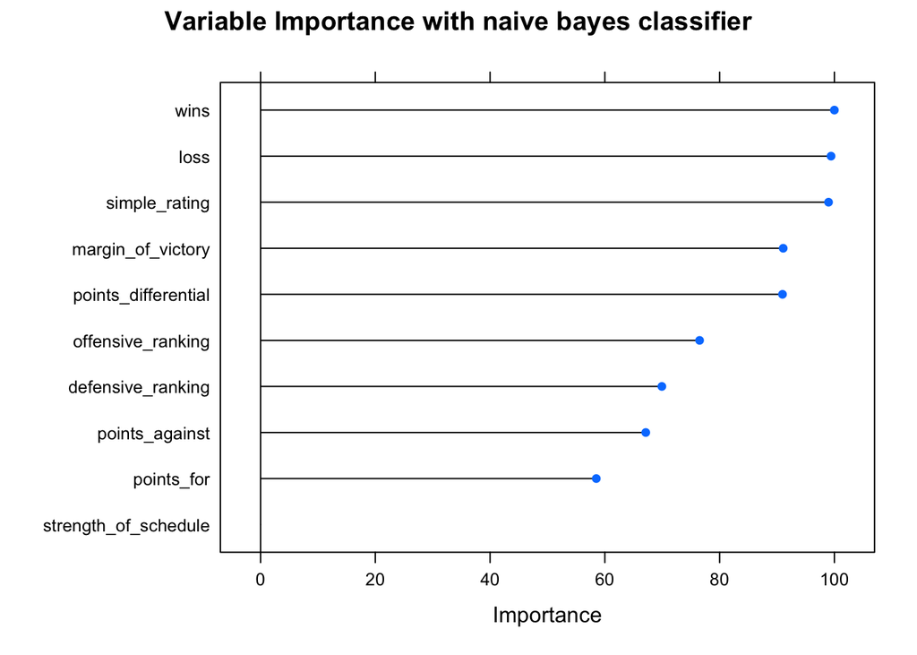

#### 6.3.2 SVM

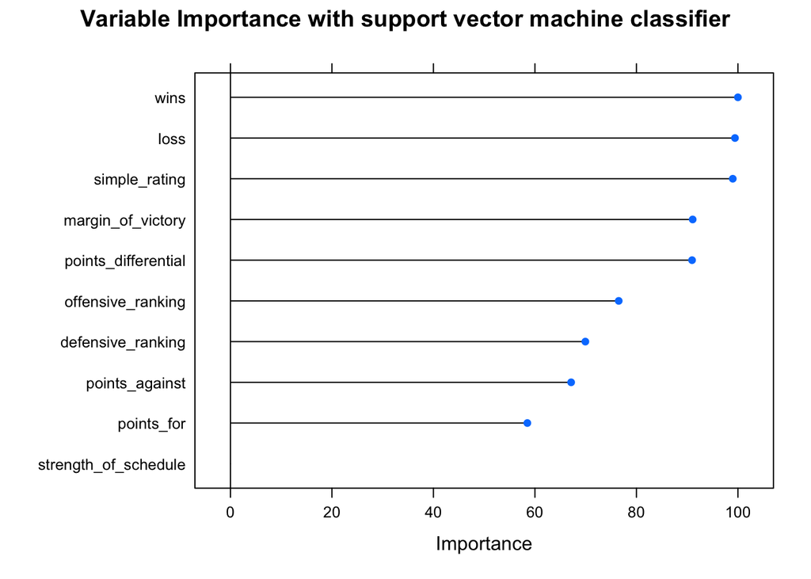

#### 6.3.3 KNN

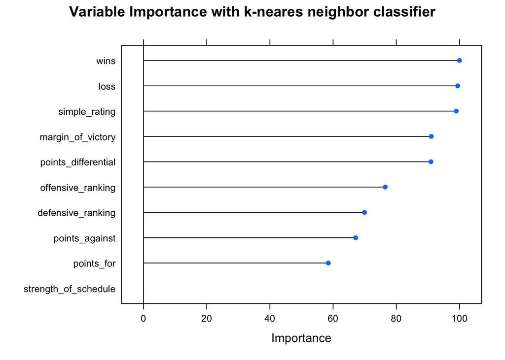

#### 6.3.4 Decision tree

[figure not shown]

[figure not shown]

## 7 Results

## 8 Conclusion